# SD Wetland Dashboard – NOAA quarto simple

Data Size (TB)

1.21

Total # of Files

186773

# Species

269

**Timeline**

[figure not shown]

Initial recordings in May included recorders deployed at Tijuana Estuary (TJE-01) and two sites at the Sweetwater Proving Pens (SPP-1N, SPP-3S). Secondary deployments were made at SPP-1N and TJE-01. A detection distance test was made at locations around the Sweetwater Proving Pens, DD01-DD10.

**Map**

[interactive chart not shown]

Interactive map with deployments at Tijuana Estuary and Sweetwater Proving Pens (at Living Coast Discovery Center). Zoom in to see exact locations of recorders, including the distribution of recorders around the proving pens for the detection distance study.

**Deployment Table**

|  | deployment_id | location | site | config_type | deploy_date | latitude | longitude | retrieve_date |
| --- | --- | --- | --- | --- | --- | --- | --- | --- |
| 1 | TJE-01_48c_20250515 | TJE | 01 | 48c | 20250515 | 32.5733189 | -117.125278 | 202550529 |
| 2 | TJE-01_48s+s_20250515 | TJE | 01 | 48s+s | 20250515 | 32.5733189 | -117.125278 | 202550529 |
| 3 | TJE-01_192b_20250515 | TJE | 01 | 192b | 20250515 | 32.5733189 | -117.125278 | 202550529 |
| 4 | SPP-1N_48c_20250515 | SPP | 1N | 48c | 20250515 | 32.6396792 | -117.1111495 | 20250602 |
| 5 | SPP-1N_48s+s_20250515 | SPP | 1N | 48s+s | 20250515 | 32.6396792 | -117.1111495 | 20250602 |
| 6 | SPP-1N_192b_20250515 | SPP | 1N | 192b | 20250515 | 32.6396792 | -117.1111495 | 20250602 |
| 7 | SPP-3S_48c_20250515 | SPP | 3S | 48c | 20250515 | 32.6394237 | -117.1113785 | 20250602 |
| 8 | SPP-3S_48s+s_20250515 | SPP | 3S | 48s+s | 20250515 | 32.6394237 | -117.1113785 | 20250602 |
| 9 | SPP-3S_192b_20250515 | SPP | 3S | 192b | 20250515 | 32.6394237 | -117.1113785 | 20250602 |
| 10 | TJE-01_48c_20250608 | TJE | 01 | 48c | 20250607 | 32.5733189 | -117.125278 | 20250712 |

[output cut: 18 more lines]

Interactive table showing all recorder deployments. We recommend viewing this on the full screen. Scroll to the bottom of the table and click on the < > symbol at the bottom right corner to open the table to full view.

**Recording Specifications**

Initial Recording Specifications

| Recording Type | Recording Schedule | Sampling Rate (kHz) | Record Off (s) | Record On (s) | Filter Type | High Pass Filter (kHz) | Low Pass Filter (kHz) |
| --- | --- | --- | --- | --- | --- | --- | --- |
| 48c | continuous | 48 | 00.00.05 | 00.00.55 | NA | NA | NA |
| 48s+s | sunriseset | 48 | 00.00.05 | 00.00.55 | NA | NA | NA |
| 192b | bat | 192 | 00.00.05 | 00.00.55 | bandpass | 12 | 96 |

Three different recording configurations were used. Continuous recording at 48 kHz (48c) provided information on diurnal variation. Sampling at Sunrise and Sunset (48s+s) provided recordings during the time when rails (and most other birds) are highly vocal. These recordings included 1 hour before and after sunrise/sunset; while these limited our ability to distinguish diurnal variation, the recording extended for a few weeks. The high frequency sampling (192b) sampled from sunset TO sunrise (night) and allowed for detection of bats.

Total # Rail Detections

9366

# Rail Calls per Hour

1.6

% Recordings with Rail Calls

3.3%

**Daily Detections**

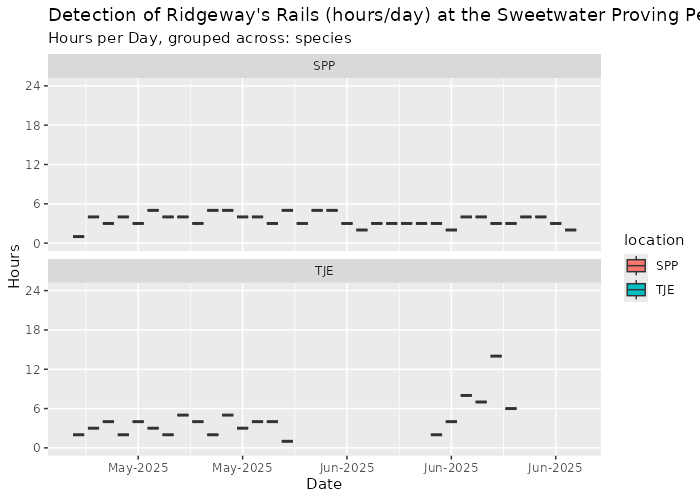

##### About this figure

Detections of sounds attributed to Ridgway’s Rails at Sweetwater Proving Pens (SPP) and Tijuana Estuary (TJE). Calls were not validated, and we expect there to be some degree of false positives (calls falsely attributed to rails) and false negatives (missed calls).

**Diurnal Detections**

Diurnal Detections

[figure not shown]

Diurnal variation in detection of calls attributed to Ridgway’s Rails.

# Species

269

Total # Detections

330397

% Recordings with Detections

42.3%

**TJ Top 10 Species**

TJ Top 10 Species

[figure not shown]

Top 10 species detected at Tijuana Estuary (TJE) over the duration of the pilot study.

**TJ Acoustic Scene**

TJ Acoustic Scene

[figure not shown]

Acoustic Scene for top ten species detected at Tijuana Estuary (TJE) over the duration of the pilot study.